# Exploring Gapminder

## Topic: Exploratory Data Analysis (EDA) on the Gapminder dataset - with a focus on the % of total roads paved across countries

- Introduction
- Data Wrangling
- Exploratory Data Analysis
- Conclusions

## Introduction

Through the [Gapminder](https://www.gapminder.org/data/) dataset, I will be exploring the relationship between the % of total roads paved and a few other parameters of interest, such as the Human Development Index (HDI), on a cross-country level.

I will only be exploring these variables through descriptive analysis, mainly through plot visualisations. As such, anything other than the mere observation of trends and patterns is beyond the goal of this exercise.

These are my research questions: 1) Is there a relationship between a country's % of total roads paved and its HDI?

- HDI is a composite, summary measurement of human development that takes three dimensions into account: life expectancy, education, and standard of living

2) What are some of the characteristics of countries with low % of total roads paved but high HDI scores, and vice versa? Parameters used here are GDP and Democracy Index.

```python
# Import libraries
import pandas as pd
import matplotlib.pyplot as plt
%matplotlib inline
import seaborn as sns
import os
import numpy as np
```

```python
os.listdir('./data/')
```

```
['service_workers_percent_of_employment.csv',
 'hdi_human_development_index.csv',
 'cars_trucks_and_buses_per_1000_persons.csv',
 'demox_eiu.csv',
 'inequality_index_gini.csv',
 'literacy_rate_adult_total_percent_of_people_ages_15_and_above.csv',
 'industry_workers_percent_of_employment.csv',
 'agriculture_workers_percent_of_employment.csv',
 'roads_paved_percent_of_total_roads.csv',
 'ny_gdp_mktp_cd.csv']
```

```python
# Import datasets
roads_paved_df = pd.read_csv('./data/roads_paved_percent_of_total_roads.csv')
hdi_df = pd.read_csv('./data/hdi_human_development_index.csv')
```

## Data Wrangling

- Explore data types of variables, make sure they are of the correct data types
- Check for missing values. If yes, first use a linear interpolation method to estimate and fill in missing values. If there are no available data to do the estimation, then I will fill them in with 0
- Make sure all datasets that I am analysing have the same list of countries

#### Explore the % of total roads paved dataset

```python
# Look at dataset
roads_paved_df.head() # Looks like data are only available from 1990 to 2009. There are missing values too
```

|  | country | 1990 | 1991 | 1992 | 1993 | 1994 | 1995 | 1996 | 1997 | 1998 | ... | 2000 | 2001 | 2002 | 2003 | 2004 | 2005 | 2006 | 2007 | 2008 | 2009 |
| --- | --- | --- | --- | --- | --- | --- | --- | --- | --- | --- | --- | --- | --- | --- | --- | --- | --- | --- | --- | --- | --- |
| 0 | Afghanistan | NaN | NaN | NaN | NaN | NaN | NaN | NaN | NaN | NaN | ... | NaN | NaN | NaN | NaN | 0.237 | 0.275 | 0.293 | NaN | NaN | NaN |
| 1 | Albania | NaN | NaN | NaN | NaN | NaN | 0.390 | 0.390 | 0.390 | 0.390 | ... | 0.390 | 0.390 | 0.39 | NaN | NaN | NaN | NaN | NaN | NaN | NaN |
| 2 | Algeria | 0.67 | 0.7 | 0.66 | 0.667 | 0.68 | 0.689 | 0.689 | 0.689 | 0.689 | ... | 0.689 | NaN | NaN | NaN | 0.702 | NaN | NaN | NaN | 0.735 | 0.74 |
| 3 | Angola | NaN | NaN | NaN | NaN | NaN | NaN | NaN | NaN | NaN | ... | 0.104 | 0.104 | NaN | NaN | NaN | NaN | NaN | NaN | NaN | NaN |
| 4 | Antigua and Barbuda | NaN | NaN | NaN | NaN | NaN | NaN | NaN | NaN | NaN | ... | NaN | NaN | 0.33 | NaN | NaN | NaN | NaN | NaN | NaN | NaN |

5 rows × 21 columns

```python
# Deal with the missing values

# Check if any country has no data at all (row-wise)
roads_paved_df.isnull().all(axis=1).sum()
```

```
0
```

```python
# Check how many missing values there are in total
print(f"Out of {roads_paved_df.shape[0] * roads_paved_df.shape[1]} values (including country names), {roads_paved_df.isnull().sum().sum()} are missing")
```

```
Out of 3801 values (including country names), 1573 are missing
```

```python
# Replace all missing values using a linear method
roads_paved_df = roads_paved_df.set_index('country').interpolate(method='linear', limit_direction='forward', axis=1)

print(f"After replacing the missing values using the linear method, {roads_paved_df.isnull().sum().sum()} are still missing")
```

```
After replacing the missing values using the linear method, 429 are still missing
```

```python
# Replace all remaining missing values with 0
roads_paved_df.fillna(0, inplace=True)

roads_paved_df.isnull().sum().sum() # Left with 0 missing values
```

```
0
```

```python
# Check the data types of each column
roads_paved_df.dtypes.value_counts() # All are floats, which is correct
```

```
float64    20
dtype: int64
```

#### Explore the HDI dataset

```python
# Look at dataset
hdi_df.head() # Looks like data are only available for more years (1990 to 2018) than the previous dataset (to 2009)
```

|  | country | 1990 | 1991 | 1992 | 1993 | 1994 | 1995 | 1996 | 1997 | 1998 | ... | 2009 | 2010 | 2011 | 2012 | 2013 | 2014 | 2015 | 2016 | 2017 | 2018 |
| --- | --- | --- | --- | --- | --- | --- | --- | --- | --- | --- | --- | --- | --- | --- | --- | --- | --- | --- | --- | --- | --- |
| 0 | Afghanistan | 0.298 | 0.304 | 0.312 | 0.308 | 0.303 | 0.327 | 0.331 | 0.335 | 0.339 | ... | 0.447 | 0.464 | 0.465 | 0.479 | 0.485 | 0.488 | 0.490 | 0.491 | 0.493 | 0.496 |
| 1 | Albania | 0.644 | 0.625 | 0.608 | 0.611 | 0.617 | 0.629 | 0.639 | 0.639 | 0.649 | ... | 0.729 | 0.740 | 0.759 | 0.771 | 0.781 | 0.787 | 0.788 | 0.788 | 0.789 | 0.791 |
| 2 | Algeria | 0.578 | 0.582 | 0.589 | 0.593 | 0.597 | 0.602 | 0.610 | 0.619 | 0.629 | ... | 0.720 | 0.730 | 0.738 | 0.737 | 0.746 | 0.749 | 0.751 | 0.755 | 0.758 | 0.759 |
| 3 | Andorra | NaN | NaN | NaN | NaN | NaN | NaN | NaN | NaN | NaN | ... | 0.830 | 0.828 | 0.827 | 0.849 | 0.846 | 0.853 | 0.850 | 0.854 | 0.852 | 0.857 |
| 4 | Angola | NaN | NaN | NaN | NaN | NaN | NaN | NaN | NaN | NaN | ... | 0.508 | 0.510 | 0.525 | 0.537 | 0.547 | 0.557 | 0.565 | 0.570 | 0.576 | 0.574 |

5 rows × 30 columns

```python
# Deal with all missing values similar to steps taken above
print(hdi_df.isnull().sum().sum()) # 517 missing values

hdi_df = hdi_df.set_index('country').interpolate(method='linear', limit_direction='forward', axis=1)
print(f"{hdi_df.isnull().sum().sum()} values are missing")

hdi_df.fillna(0, inplace=True)
print(f"{hdi_df.isnull().sum().sum()} values are missing")
```

```
517
515 values are missing
0 values are missing
```

```python
hdi_df.dtypes.value_counts() # All columns are in the correct data types
```

```
float64    29
dtype: int64
```

## Exploratory Data Analysis

### Research Question 1:

> Is there a difference in the HDI scores of countries with high and low % of total roads paved?

I want to see if there is a correlation between the % of roads paved in a country and its HDI score. But first, I'd need to compare the two datasets (roads_paved_df and hdi_df) to check if all countries and years of each dataset are also found in the other.

```python
# Check for the list of countries in each dataset
print(f"There are {roads_paved_df.index.nunique()} unique countries in roads_paved_df and {hdi_df.index.nunique()} \
unique countries in hdi_df")
```

```
There are 181 unique countries in roads_paved_df and 188 unique countries in hdi_df
```

```python
# Identify which countries that are not found in both datasets
countries_hdi_list = hdi_df.index.unique().tolist()
countries_roads_paved_list = roads_paved_df.index.unique().tolist()

# These countries are in hdi_df, but not in roads_paved_df
remove_in_hdi_df = hdi_df.index[~hdi_df.index.isin(countries_roads_paved_list)].tolist()
remove_in_hdi_df
```

```
['Andorra',
 'Equatorial Guinea',
 'Kiribati',
 'Liechtenstein',
 'Marshall Islands',
 'Montenegro',
 'Palau',
 'South Sudan',
 'St. Lucia',
 'Timor-Leste']
```

```python
# Whereas these countries are in roads_paved_df, but not in hdi_df
remove_in_roads_paved_df = roads_paved_df.index[~roads_paved_df.index.isin(countries_hdi_list)].tolist()
remove_in_roads_paved_df
```

```
['Monaco', 'North Korea', 'Somalia']
```

```python
# Remove above countries in their respective datasets
roads_paved_df.reset_index(inplace=True)
roads_paved_df = roads_paved_df[~roads_paved_df['country'].isin(remove_in_roads_paved_df)]

hdi_df.reset_index(inplace=True)
hdi_df = hdi_df[~hdi_df['country'].isin(remove_in_hdi_df)]

# Re-check number of unique countries in each df
print(f"There are {roads_paved_df.index.nunique()} unique countries in roads_paved_df and {hdi_df.index.nunique()} \
unique countries in hdi_df")
```

```
There are 178 unique countries in roads_paved_df and 178 unique countries in hdi_df
```

```python
# Double confirm that all unique countries in each df are the same
assert roads_paved_df['country'].reset_index(drop=True).to_frame().equals(hdi_df['country'].reset_index(drop=True).to_frame())
```

I will first plot a bar chart showing the distribution of total roads paved across various countries in the most available recent year, 2009. This is for me to get an overview of a cross-country situation of total roads paved.

We can see from the chart that there is a wide variation in my indicator of interest.

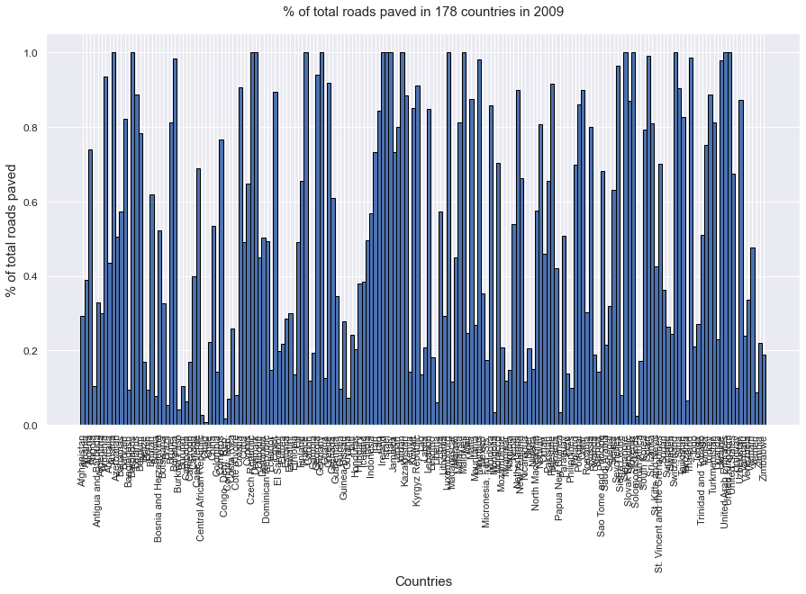

```python
sns.set()
fig = plt.figure(figsize=(15,8))
plt.bar(roads_paved_df['country'], roads_paved_df['2009'], width=1, edgecolor='black')
plt.title('% of total roads paved in 178 countries in 2009', fontsize=15, pad=20)
plt.xlabel('Countries', fontsize=15)
plt.ylabel('% of total roads paved', fontsize=15)
plt.xticks(rotation=90)
plt.yticks(fontsize=12);
```

```python
# There are countries with a 100% of total roads paved
print(roads_paved_df[roads_paved_df['2009'] == 1]['country'].tolist())
```

```
['Austria', 'Barbados', 'Czech Republic', 'Denmark', 'France', 'Germany', 'Ireland', 'Israel', 'Italy', 'Jordan', 'Luxembourg', 'Maldives', 'Singapore', 'Slovenia', 'Switzerland', 'United Arab Emirates', 'United Kingdom']
```

```python
# Whereas these are countries with less than 20% of roads paved
print(roads_paved_df[roads_paved_df['2009'] < 0.2]['country'].tolist())
```

[output not shown]

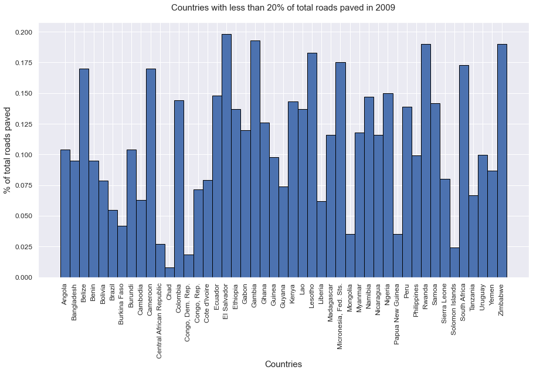

```python
# Bar chart showing countries with the lowest (less than 20%) % of total roads paved in 2009
sns.set()
fig = plt.figure(figsize=(15,8))
plt.bar(roads_paved_df[roads_paved_df['2009'] < 0.2]['country'],
        roads_paved_df[roads_paved_df['2009'] < 0.2]['2009'], width=1, edgecolor='black')
plt.title('Countries with less than 20% of total roads paved in 2009', fontsize=15, pad=20)
plt.xlabel('Countries', fontsize=15)
plt.ylabel('% of total roads paved', fontsize=15)
plt.xticks(fontsize=12, rotation=90)
plt.yticks(fontsize=12);
```

Now, let's look at the relationship between % total roads paved and HDI scores in 2009 in a scatter plot diagram.

Since I will be plotting several scatter plots throughout this exercise, I will define a function for it.

```python
def plot_scatter(x_series,
                 y_series,
                 title,
                 x_title,
                 y_title):
    """Plot scatter plot"""
    fig = plt.figure(figsize=(15,8))
    plt.scatter(x_series, y_series)
    plt.title(title, fontsize=15, pad=20)
    plt.xlabel(x_title, fontsize=15)
    plt.ylabel(y_title, fontsize=15)
    plt.xticks(fontsize=12)
    plt.yticks(fontsize=12);
```

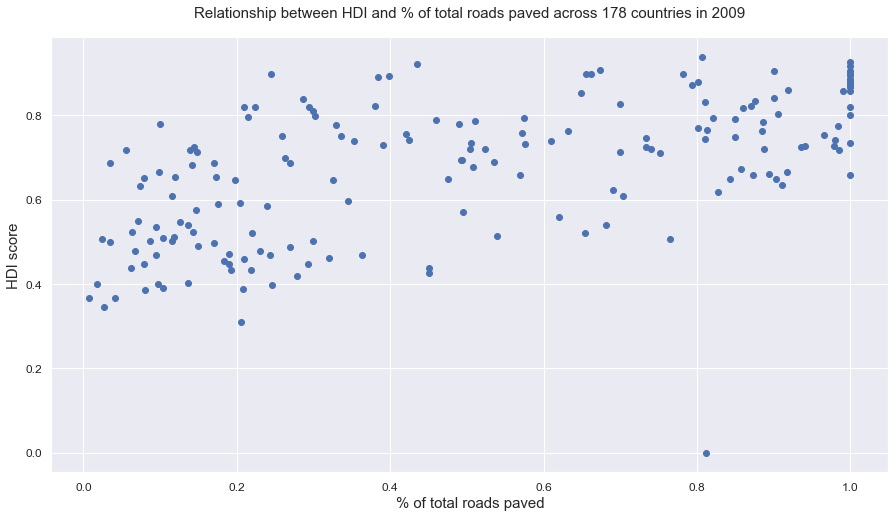

```python
plot_scatter(roads_paved_df['2009'], hdi_df['2009'],
             'Relationship between HDI and % of total roads paved across 178 countries in 2009',
             '% of total roads paved',
             'HDI score')
```

Generally, we can see a positive correlation between both these variables, suggesting that as the total number of roads paved in a country increases, the country's HDI score increases too!

There is however, an obvious outlier in the chart - right at the bottom.

```python
# Look for that outlier at the bottom of the chart
roads_paved_outlier = roads_paved_df[roads_paved_df['2009'] > 0.8][['country','2009']]

hdi_df_outlier = hdi_df[hdi_df['country'].isin(roads_paved_outlier['country'].tolist())][['country','2009']]

roads_paved_hdi_outlier = pd.merge(left=roads_paved_outlier, right=hdi_df_outlier,
                                   left_on='country', right_on='country',
                                   suffixes=['_roads_paved', '_hdi'])

outlier = roads_paved_hdi_outlier[(roads_paved_hdi_outlier['2009_roads_paved'] < 0.9) &
                                  (roads_paved_hdi_outlier['2009_hdi'] < 0.2)]

print(f"{outlier['country'].values[0]} has a high % of roads paved at {outlier['2009_roads_paved'].values[0]} \
but a low HDI score at {outlier['2009_hdi'].values[0]}")
```

```
Turkmenistan has a high % of roads paved at 0.812 but a low HDI score at 0.0
```

```python
# Look at the HDI scores for Turkmenistan across the years
hdi_df[hdi_df['country'] == 'Turkmenistan']
```

|  | country | 1990 | 1991 | 1992 | 1993 | 1994 | 1995 | 1996 | 1997 | 1998 | ... | 2009 | 2010 | 2011 | 2012 | 2013 | 2014 | 2015 | 2016 | 2017 | 2018 |
| --- | --- | --- | --- | --- | --- | --- | --- | --- | --- | --- | --- | --- | --- | --- | --- | --- | --- | --- | --- | --- | --- |
| 174 | Turkmenistan | 0.0 | 0.0 | 0.0 | 0.0 | 0.0 | 0.0 | 0.0 | 0.0 | 0.0 | ... | 0.0 | 0.673 | 0.68 | 0.686 | 0.691 | 0.696 | 0.701 | 0.706 | 0.708 | 0.71 |

1 rows × 30 columns

Seems like the country's HDI scores are only available post-2009. Taking the starting score of 0.6+, Turkmenistan wouldn't have been an outlier in this relationship anymore.

```python
# Fill in Turkmenistan's missing 2009 data with the 2010 one
hdi_df.loc[174, '2009'] = 0.673
```

### Research Question 2:

> What are some of the characteristics of countries with low % of total roads paved but high HDI scores, and vice versa?

As described in this [World Bank study](https://blogs.worldbank.org/transport/do-better-roads-really-improve-lives), the notion put forth was that improved roads led to better socio-economic outcomes for people who particularly reside in rural communities.

To some degree or another, better socio-economic outcomes are necessarily associated with higher education, health, and economic opportunities - all of which may be simplistically summarised in the HDI scores.

And indeed, the scatter plot above does show me a positive correlation between % of total roads paved and HDI scores.

In this regard, why do some countries perform surprisingly better, whereas some perform surprisingly worse?

Of course, I am taking an over-simplified view that the total roads paved in a country is the primary indicator of a populations' state of well-being (it is more complex than that).

Nevertheless, let's throw in some other indicators to see if there exist any patterns or characteristics of countries that either ride with or against the general trend of positively correlated relationship between % of total roads paved and HDI scores in 2009.

Let's first look at the Gross Domestic Product (GDP) of the countries, which I take it to be a general proxy of a nation's economic wealth.

```python
gdp_df = pd.read_csv('./data/ny_gdp_mktp_cd.csv')

gdp_df.head()

print(f"There are {len(gdp_df['country'].unique())} unique countries in this gdp dataset")
```

```
There are 193 unique countries in this gdp dataset
```

```python
# Only want the 2009 data, and countries with data on % of total roads paved
countries_include = roads_paved_df['country'].tolist()

gdp_df = gdp_df[gdp_df['country'].isin(countries_include)]

print(f"Now, there remains {len(gdp_df['country'].unique())} unique countries in this gdp dataset")
```

```
Now, there remains 178 unique countries in this gdp dataset
```

```python
# Check out how many missing data there are from the 2009 column
gdp_df['2009'].isnull().sum() # Only one value is missing
```

```
1
```

```python
# Which country is missing this 2009 gdp value?
gdp_df[gdp_df['2009'].isnull()] # Syria
```

|  | country | 1960 | 1961 | 1962 | 1963 | 1964 | 1965 | 1966 | 1967 | 1968 | ... | 2010 | 2011 | 2012 | 2013 | 2014 | 2015 | 2016 | 2017 | 2018 | 2019 |
| --- | --- | --- | --- | --- | --- | --- | --- | --- | --- | --- | --- | --- | --- | --- | --- | --- | --- | --- | --- | --- | --- |
| 168 | Syria | 858000000.0 | 945000000.0 | 1.110000e+09 | 1.200000e+09 | 1.340000e+09 | 1.470000e+09 | 1.340000e+09 | 1.580000e+09 | 1.750000e+09 | ... | NaN | NaN | NaN | NaN | NaN | NaN | NaN | NaN | NaN | NaN |

1 rows × 61 columns

For the sake of handling this missing figure of Syria's GDP value in 2009, I will use the forward linear interpolation method to fill in the blank value.

```python
gdp_df = gdp_df.set_index('country').interpolate(method='linear', limit_direction='forward', axis=1).reset_index()

gdp_df['2009'].isnull().sum() # There are now 0 missing values.
```

```
0
```

Now, I will create a new df containing only the 2009 data for % total roads paved, HDI scores, and GDP.

Having all the data for analysis in a single dataframe makes it more convenient to do calculations.

```python
roads_paved_hdi_gdp_df = pd.merge(left=roads_paved_df[['country','2009']], right=hdi_df[['country','2009']],
                                  left_on='country', right_on='country', suffixes=['_roads_paved','_hdi'])

roads_paved_hdi_gdp_df = pd.merge(left=roads_paved_hdi_gdp_df, right=gdp_df[['country','2009']],
                                  left_on='country', right_on='country')

roads_paved_hdi_gdp_df.rename(columns={'2009':'2009_gdp'}, inplace=True)

roads_paved_hdi_gdp_df.head()
```

|  | country | 2009_roads_paved | 2009_hdi | 2009_gdp |
| --- | --- | --- | --- | --- |
| 0 | Afghanistan | 0.293 | 0.447 | 1.240000e+10 |
| 1 | Albania | 0.390 | 0.729 | 1.200000e+10 |
| 2 | Algeria | 0.740 | 0.720 | 1.370000e+11 |
| 3 | Angola | 0.104 | 0.508 | 7.030000e+10 |
| 4 | Antigua and Barbuda | 0.330 | 0.776 | 1.230000e+09 |

Next, I will group the countries into four categories for comparison sake:

- Countries with high % of total roads paved and high HDI scores (upper right quadrant);
- Countries with high % of total roads paved but low HDI scores (bottom right quadrant);
- Countries with low % of total roads paved and low HDI scores (bottom left quadrant); and
- Countries with low % of total roads paved but high HDI scores (upper left quadrant).

I will take 50% and 0.5 as the cut-off marks for countries with either high or low % total roads paved and either high or low HDI scores.

```python
quadrants = np.where((roads_paved_hdi_gdp_df['2009_roads_paved'] >= 0.5) & (roads_paved_hdi_gdp_df['2009_hdi'] >= 0.5),
           'high_paved_high_hdi',
            np.where((roads_paved_hdi_gdp_df['2009_roads_paved'] >= 0.5) & (roads_paved_hdi_gdp_df['2009_hdi'] < 0.5),
           'high_paved_low_hdi',
            np.where((roads_paved_hdi_gdp_df['2009_roads_paved'] < 0.5) & (roads_paved_hdi_gdp_df['2009_hdi'] < 0.5),
           'low_paved_low_hdi',
           'low_paved_high_hdi')))

roads_paved_hdi_gdp_df['quadrant_group'] = quadrants

# Check if all quadrant groups are filled based on the conditions above
roads_paved_hdi_gdp_df['quadrant_group'].value_counts()
```

```
high_paved_high_hdi    84
low_paved_high_hdi     62
low_paved_low_hdi      32
Name: quadrant_group, dtype: int64
```

I am mostly interested in the 'outlier' groups: low_paved_high_hdi group (seeing as none are in the high_paved_low_hdi group).

Let's look at the economic situations of countries that fall within each quadrant as above.

```python
# Initialise an empty dictionary to store the gdp data separately for each quadrant group
gdp_quadrant_dict = {}

quadrant_list = ['high_paved_high_hdi', 'low_paved_high_hdi', 'low_paved_low_hdi']

for i in quadrant_list:
    gdp_quadrant_dict[i] = roads_paved_hdi_gdp_df[roads_paved_hdi_gdp_df['quadrant_group'] == i]['2009_gdp'].tolist()
```

```python
def plot_boxplot(quadrant_group_dict,
                 title,
                 x_title,
                 y_title):
    """Plot boxplot for each quagdrant group"""
    fig = plt.figure(figsize=(15,8))
    plt.boxplot(quadrant_group_dict.values())
    plt.title(title, fontsize=15, pad=20)
    plt.xlabel(x_title, fontsize=15)
    plt.ylabel(y_title, fontsize=15)
    plt.xticks([1, 2, 3],['High % Roads Paved, High HDI','Low % Roads Paved, High HDI','Low % Roads Paved, Low HDI'],
               fontsize=12)
    plt.yticks(fontsize=12);
```

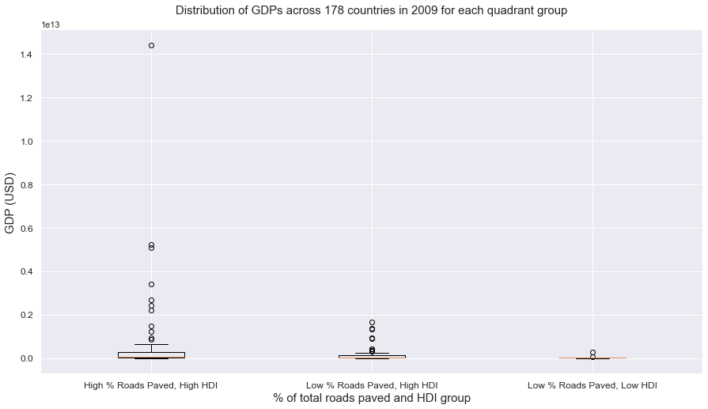

```python
plot_boxplot(gdp_quadrant_dict,
             'Distribution of GDPs across 178 countries in 2009 for each quadrant group',
             '% of total roads paved and HDI group',
             'GDP (USD)')
```

```python
print(f"The outlier country belongs to {roads_paved_hdi_gdp_df.set_index('country')['2009_gdp'].idxmax()}")
```

```
The outlier country belongs to United States
```

Say I remove the US from the boxplot just so that I am able to gain a zoomed in view of the remaining data.

```python
roads_paved_hdi_gdp_df_remove_US = roads_paved_hdi_gdp_df.drop([169], axis=0) # Index for the US

# Number of unique countries now should be 177
assert len(roads_paved_hdi_gdp_df_remove_US) == 177
```

```python
# Reprep data without the US

# Initialise an empty dictionary to store the gdp data separately for each quadrant group
gdp_quadrant_dict_without_US = {}

quadrant_list = ['high_paved_high_hdi', 'low_paved_high_hdi', 'low_paved_low_hdi']

for i in quadrant_list:
    gdp_quadrant_dict_without_US[i] = roads_paved_hdi_gdp_df_remove_US[
                           roads_paved_hdi_gdp_df_remove_US['quadrant_group'] == i]['2009_gdp'].tolist()
```

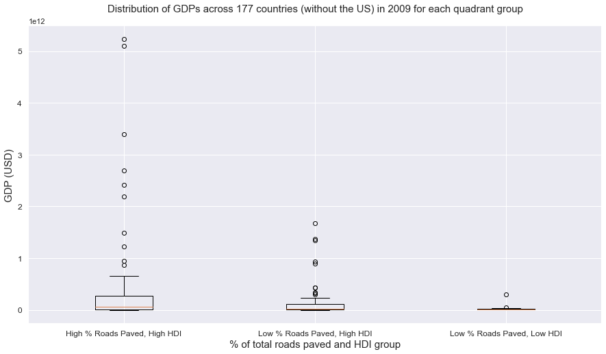

```python
# Replot boxplot without the US outlier data
plot_boxplot(gdp_quadrant_dict_without_US,
             'Distribution of GDPs across 177 countries (without the US) in 2009 for each quadrant group',
             '% of total roads paved and HDI group',
             'GDP (USD)')
```

Here, we see that there are many more outlier countries with very high GDP levels in countries with higher HDIs, suggesting an at least, somewhat positive correlation between GDP and HDI. I say somewhat because out of the 177 countries, we only see a handful of outliers. Meaning, a country's GDP would not be the strongest predictor either of a country's HDI.

Secondly, we do also see major overlaps in the boxplots between the three groups, suggesting that a country's GDP may not play a significant role in determining how much of its total roads are paved either.

These observations are confirmed in the scatter plots below.

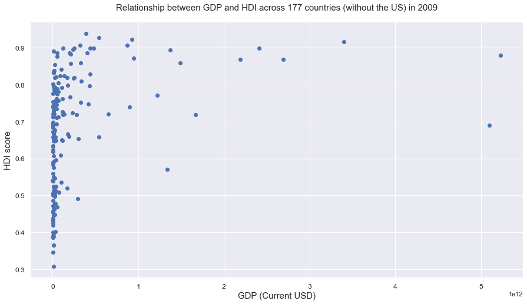

```python
plot_scatter(roads_paved_hdi_gdp_df_remove_US['2009_gdp'], roads_paved_hdi_gdp_df_remove_US['2009_hdi'],
             'Relationship between GDP and HDI across 177 countries (without the US) in 2009',
             'GDP (Current USD)',
             'HDI score')
```

[figure not shown]

```python
plot_scatter(roads_paved_hdi_gdp_df_remove_US['2009_gdp'], roads_paved_hdi_gdp_df_remove_US['2009_roads_paved'],
             'Relationship between GDP and HDI across 177 countries (without the US) in 2009',
             'GDP (Current USD)',
             '% total roads paved')
```

Hmm...seems like GDP isn't such a great predictor of a country's % of roads paved and HDI score.

Let's explore another indicator: Democracy index - expresses the quality of democracies as a number between 0 to 100 %. It is based on 60 different parameters that are related to a country's democratic nature, such as voter participation, perception of human rights protection, and freedom to form organizations and parties.

```python
demo_df = pd.read_csv('./data/demox_eiu.csv')

len(demo_df)
```

```
164
```

```python
# Get countries from the democracy df that have data on roads_paved, HDI, GDP
print(f"There are {len(demo_df['country'].unique())} unique countries in this literacy dataset")
```

```
There are 164 unique countries in this literacy dataset
```

There are less countries with data on democracy index (164 unique countries) than in our combined dataset of roads paved %, HDI, and GDP (178 unique countries).

I'd need to make sure all countries match between both datasets.

```python
demo_countries = demo_df['country'].tolist()

roads_paved_hdi_gdp_demo_df = roads_paved_hdi_gdp_df[roads_paved_hdi_gdp_df['country'].isin(demo_countries)]

print(f"After removing countries in the original df that are not found in the democracy df, there remains \
{len(roads_paved_hdi_gdp_demo_df['country'].unique())} unique countries in the original dataset")
```

```
After removing countries in the original df that are not found in the democracy df, there remains 160 unique countries in the original dataset
```

```python
new_countries = roads_paved_hdi_gdp_demo_df['country'].tolist()

demo_df = demo_df[demo_df['country'].isin(new_countries)]

print(f"Finally, {len(demo_df['country'].unique())} unique countries are left in the democracy dataset that are \
also found in the original df")
```

```
Finally, 160 unique countries are left in the democracy dataset that are also found in the original df
```

```python
# Confirm all countries are the same in both dfs
assert demo_df['country'].tolist() == roads_paved_hdi_gdp_demo_df['country'].tolist()
```

Since we only want the 2009 democracy data, I will need to check for any missing values. If yes, the I'd need to fill in these missing values with how I had done so before - linear, forward method of interpolation.

```python
demo_df['2009'].isnull().sum() # no missing values
```

```
0
```

```python
# Merge 2009 democracy data to the original, combined dataset
demo_df = demo_df[['country', '2009']]

roads_paved_hdi_gdp_demo_df = pd.merge(left = demo_df, right = roads_paved_hdi_gdp_demo_df,
                                       left_on = 'country', right_on = 'country')

roads_paved_hdi_gdp_demo_df.rename(columns = {'2009':'2009_democracy'}, inplace = True)

roads_paved_hdi_gdp_demo_df.head()
```

|  | country | 2009_democracy | 2009_roads_paved | 2009_hdi | 2009_gdp | quadrant_group |
| --- | --- | --- | --- | --- | --- | --- |
| 0 | Afghanistan | 0.275 | 0.293 | 0.447 | 1.240000e+10 | low_paved_low_hdi |
| 1 | Albania | 0.589 | 0.390 | 0.729 | 1.200000e+10 | low_paved_high_hdi |
| 2 | Algeria | 0.338 | 0.740 | 0.720 | 1.370000e+11 | high_paved_high_hdi |
| 3 | Angola | 0.334 | 0.104 | 0.508 | 7.030000e+10 | low_paved_high_hdi |
| 4 | Argentina | 0.673 | 0.300 | 0.810 | 3.330000e+11 | low_paved_high_hdi |

```python
# Initialise an empty dictionary to store the democracy data separately for each quadrant group - similar to before
demo_quadrant_dict = {}

quadrant_list = ['high_paved_high_hdi', 'low_paved_high_hdi', 'low_paved_low_hdi']

for i in quadrant_list:
    demo_quadrant_dict[i] = roads_paved_hdi_gdp_demo_df[
                            roads_paved_hdi_gdp_demo_df['quadrant_group'] == i]['2009_democracy'].tolist()
```

[figure not shown]

```python
plot_boxplot(demo_quadrant_dict,
             'Distribution of GDPs across 160 countries in 2009 for each quadrant group',
             '% of total roads paved and HDI group',
             'Democracy Index')
```

Again, major overlaps in the boxplots may be observed between the quadrant of interest (low % roads but high HDI) and the other two, suggesting that a country's democracy index is not as strong of a predictor of its total roads paved as compared to its HDI score.

Confirmed in the scatter plots below.

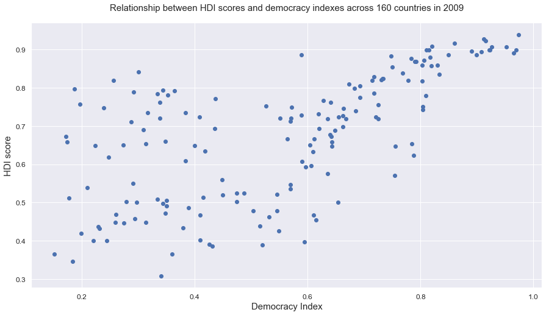

```python
plot_scatter(roads_paved_hdi_gdp_demo_df['2009_democracy'], roads_paved_hdi_gdp_demo_df['2009_hdi'],
             'Relationship between HDI scores and democracy indexes across 160 countries in 2009',
             'Democracy Index',
             'HDI score')
```

[figure not shown]

```python
plot_scatter(roads_paved_hdi_gdp_demo_df['2009_democracy'], roads_paved_hdi_gdp_demo_df['2009_hdi'],
             'Relationship between % roads paved and democracy indexes across 160 countries in 2009',
             'Democracy Index',
             '% total roads paved')
```